# Cluster analysis

## Cluster Analysis

- One side-effect of discriminant analysis: could draw picture of data (if 1st 2s `LD`s told most of story) and see which individuals “close” to each other.
- Discriminant analysis requires knowledge of groups.
- Without knowledge of groups, use *cluster analysis*: see which individuals close, which groups suggested by data.
- Idea: see how individuals group into “clusters” of nearby individuals.
- Base on “dissimilarities” between individuals.
- Or base on standard deviations and correlations between variables (assesses dissimilarity behind scenes).

## Packages

```r
library(MASS) # for lda later
library(tidyverse)
library(ggrepel)
library(MVTests) # for Box M
```

## One to ten in 11 languages

## Dissimilarities and languages example

- Can define dissimilarities how you like (whatever makes sense in application).
- Sometimes defining “similarity” makes more sense; can turn this into dissimilarity by subtracting from some maximum.
- Example: numbers 1–10 in various European languages. Define similarity between two languages by counting how often the same number has a name starting with the same letter (and dissimilarity by how often number has names starting with different letter).
- Crude (doesn’t even look at most of the words), but see how effective.

## Two kinds of cluster analysis

- Looking at process of forming clusters (of similar languages): (`hclust`).
  - Start with each individual in cluster by itself.
  - Join “closest” clusters one by one until all individuals in one cluster.
  - How to define closeness of two *clusters*? Not obvious, investigate in a moment.
- Know how many clusters: which division into that many clusters is “best” for individuals? (`kmeans`).

## Two made-up clusters

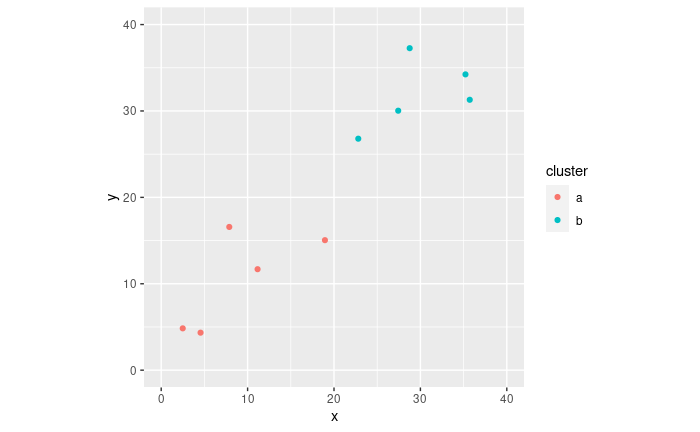

```r
set.seed(457299)
a=data.frame(x=runif(5,0,20),y=runif(5,0,20))
b=data.frame(x=runif(5,20,40),y=runif(5,20,40))
ddd=bind_rows(a=a,b=b,.id="cluster")
g=ggplot(ddd,aes(x=x,y=y,colour=cluster))+geom_point()+
  coord_fixed(xlim=c(0,40),ylim=c(0,40))
g
```

How to measure distance between set of red points and set of blue ones?

## Single-linkage distance

Find the red point and the blue point that are closest together:

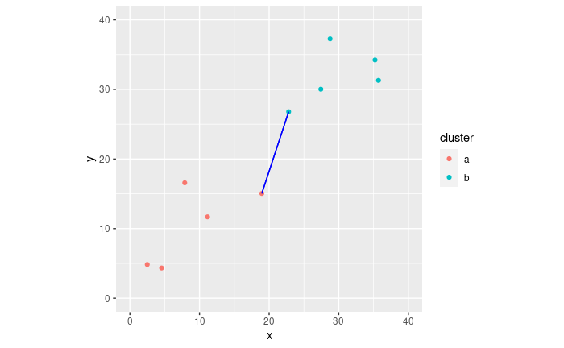

```r
distance=function(p1,p2) {
  as.numeric(sqrt((p1[1]-p2[1])^2+(p1[2]-p2[2])^2))
}
distances=matrix(0,nrow(a),nrow(b))
for (i in 1:nrow(a)) {
  for (j in 1:nrow(b)) {
    dd=distance(a[i,],b[j,])
    distances[i,j]=dd
  }
}
wm1=which.min(apply(distances,1,min))
wm2=which.min(apply(distances,2,min))
closest=bind_rows(a=a[wm1,],b=b[wm2,],.id="cluster")
# single linkage distance
g+geom_segment(data=closest,aes(x=x[1],y=y[1],xend=x[2],yend=y[2]),colour="blue")
```

Single-linkage distance between 2 clusters is distance between their closest points.

## Complete linkage

Find the red and blue points that are farthest apart:

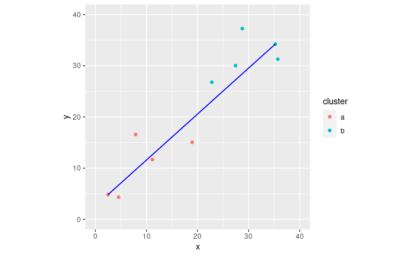

```r
wm1=which.max(apply(distances,1,max))
wm2=which.max(apply(distances,2,max))
closest=bind_rows(a[wm1,],b[wm2,],.id="cluster")
g+geom_segment(data=closest,aes(x=x[1],y=y[1],xend=x[2],yend=y[2]),colour="blue")
```

Complete-linkage distance is distance between farthest points.

## Ward’s method

Work out mean of each cluster and join point to its mean:

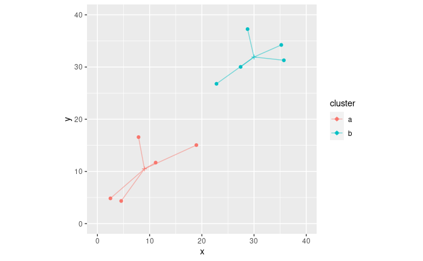

```r
xm=aggregate(x~cluster,ddd,mean)
ym=aggregate(y~cluster,ddd,mean)
dm=cbind(xm,y=ym[,2])
# loop through data frame and create grp that links to cluster's mean
new=data.frame(x=double(),y=double(),cluster=character(),grp=integer(),
  stringsAsFactors = F)
count=0;
for (i in 1:5) {
  count=count+1
  new[2*count-1,]=c(a[i,],cluster="a",grp=count)
  new[2*count,]=c(dm[1,-1],cluster="a",grp=count)
  count=count+1
  new[2*count-1,]=c(b[i,],cluster="b",grp=count)
  new[2*count,]=c(dm[2,-1],cluster="b",grp=count)
}
ggplot(ddd,aes(x=x,y=y,colour=cluster))+
  coord_fixed(xlim=c(0,40),ylim=c(0,40))+
  geom_point()+
  geom_point(data=dm,shape=3)+
  geom_line(data=new,aes(group=grp),alpha=0.5)
```

1. Work out sum of squared distances of points from means.

## Ward’s method part 2

Now imagine combining the two clusters and working out overall mean. Join each point to this mean:

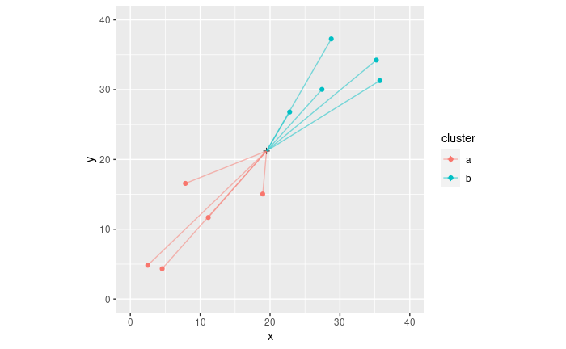

```r
ddd %>% summarize(x=mean(x),y=mean(y)) -> dm
# loop through data frame and create grp that links to cluster's mean
new=data.frame(x=double(),y=double(),cluster=character(),grp=integer(),
  stringsAsFactors = F)
count=0;
for (i in 1:5) {
  count=count+1
  new[2*count-1,]=c(a[i,],cluster="a",grp=count)
  new[2*count,]=c(dm[1,],cluster="a",grp=count)
  count=count+1
  new[2*count-1,]=c(b[i,],cluster="b",grp=count)
  new[2*count,]=c(dm[1,],cluster="b",grp=count)
}
ggplot(ddd,aes(x=x,y=y,colour=cluster))+
  coord_fixed(xlim=c(0,40),ylim=c(0,40))+
  geom_point()+
  geom_point(data=dm,aes(colour=NULL),shape=3)+
  geom_line(data=new,aes(group=grp),alpha=0.5)
```

2. Calc sum of squared distances of points to combined mean.

## Hierarchical clustering revisited

- Single linkage, complete linkage, Ward are ways of measuring closeness of clusters.
- Use them, starting with each observation in own cluster, to repeatedly combine two closest clusters until all points in one cluster.
- They will give different answers (clustering stories).
- Single linkage tends to make “stringy” clusters because clusters can be very different apart from two closest points.
- Complete linkage insists on whole clusters being similar.
- Ward tends to form many small clusters first.

## Dissimilarity data in R

Dissimilarities for language data were how many number names had *different* first letter:

```r
options(width=60)
```

```r
my_url="http://ritsokiguess.site/datafiles/languages.txt"
number.d=read_table(my_url)
number.d
```

| la | en | no | dk | nl | de | fr | es | it | pl | hu | fi |
| --- | --- | --- | --- | --- | --- | --- | --- | --- | --- | --- | --- |
| en | 0 | 2 | 2 | 7 | 6 | 6 | 6 | 6 | 7 | 9 | 9 |
| no | 2 | 0 | 1 | 5 | 4 | 6 | 6 | 6 | 7 | 8 | 9 |
| dk | 2 | 1 | 0 | 6 | 5 | 6 | 5 | 5 | 6 | 8 | 9 |
| nl | 7 | 5 | 6 | 0 | 5 | 9 | 9 | 9 | 10 | 8 | 9 |
| de | 6 | 4 | 5 | 5 | 0 | 7 | 7 | 7 | 8 | 9 | 9 |
| fr | 6 | 6 | 6 | 9 | 7 | 0 | 2 | 1 | 5 | 10 | 9 |
| es | 6 | 6 | 5 | 9 | 7 | 2 | 0 | 1 | 3 | 10 | 9 |
| it | 6 | 6 | 5 | 9 | 7 | 1 | 1 | 0 | 4 | 10 | 9 |
| pl | 7 | 7 | 6 | 10 | 8 | 5 | 3 | 4 | 0 | 10 | 9 |
| hu | 9 | 8 | 8 | 8 | 9 | 10 | 10 | 10 | 10 | 0 | 8 |

[output cut: 1 more lines]

## Making a distance object

```r
d = number.d %>%
    select(-la) %>%
    as.dist()
d
```

```
   en no dk nl de fr es it pl hu
no  2
dk  2  1
nl  7  5  6
de  6  4  5  5
fr  6  6  6  9  7
es  6  6  5  9  7  2
it  6  6  5  9  7  1  1
pl  7  7  6 10  8  5  3  4
hu  9  8  8  8  9 10 10 10 10
fi  9  9  9  9  9  9  9  8  9  8
```

```r
class(d)
```

```
[1] "dist"
```

## Cluster analysis and dendrogram

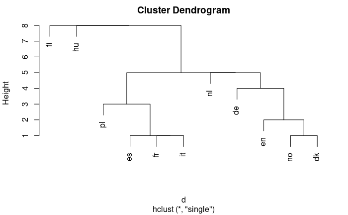

```r
d.hc=hclust(d,method="single")
plot(d.hc)
```

## Comments

- Tree shows how languages combined into clusters.
- First (bottom), Spanish, French, Italian joined into one cluster, Norwegian and Danish into another.
- Later, English joined to Norse languages, Polish to Romance group.
- Then German, Dutch make a Germanic group.
- Finally, Hungarian and Finnish joined to each other and everything else.

## Clustering process

```r
d.hc$labels
```

```
 [1] "en" "no" "dk" "nl" "de" "fr" "es" "it" "pl" "hu" "fi"
```

```r
d.hc$merge
```

```
      [,1] [,2]
 [1,]   -2   -3
 [2,]   -6   -8
 [3,]   -7    2
 [4,]   -1    1
 [5,]   -9    3
 [6,]   -5    4
 [7,]   -4    6
 [8,]    5    7
 [9,]  -10    8
[10,]  -11    9
```

- Lines of `merge` show what was combined
  - First, languages 2 and 3 (`no` and `dk`)
  - Then languages 6 and 8 (`fr` and `it`)
  - Then #7 combined with cluster formed at step 2 (`es` joined to `fr` and `it`).
  - Then `en` joined to `no` and `dk` …
  - Finally `fi` joined to all others.

## Complete linkage

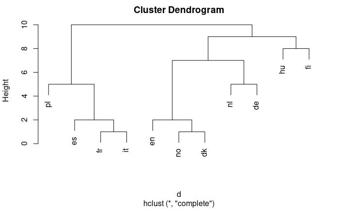

```r
d.hc=hclust(d,method="complete")
plot(d.hc)
```

## Ward

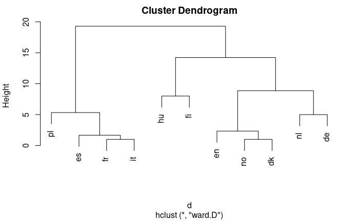

```r
d.hc=hclust(d,method="ward.D")
plot(d.hc)
```

## Chopping the tree

- Three clusters (from Ward) looks good:

```r
cutree(d.hc,3)
```

```
en no dk nl de fr es it pl hu fi
 1  1  1  1  1  2  2  2  2  3  3
```

## Drawing those clusters on the tree

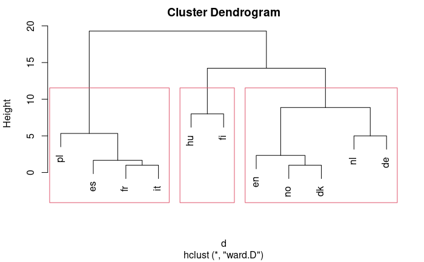

```r
plot(d.hc)
rect.hclust(d.hc,3)
```

## Comparing single-linkage and Ward

- In Ward, Dutch and German get joined earlier (before joining to Germanic cluster).
- Also Hungarian and Finnish get combined earlier.

## Making those dissimilarities

Original data:

```r
options(width=60)
```

```r
my_url="http://ritsokiguess.site/datafiles/one-ten.txt"
lang=read_delim(my_url," ")
lang
```

| en | no | dk | nl | de | fr | es | it | pl | hu | fi |
| --- | --- | --- | --- | --- | --- | --- | --- | --- | --- | --- |
| one | en | en | een | eins | un | uno | uno | jeden | egy | yksi |
| two | to | to | twee | zwei | deux | dos | due | dwa | ketto | kaksi |
| three | tre | tre | drie | drei | trois | tres | tre | trzy | harom | kolme |
| four | fire | fire | vier | vier | quatre | cuatro | quattro | cztery | negy | nelja |
| five | fem | fem | vijf | funf | cinq | cinco | cinque | piec | ot | viisi |
| six | seks | seks | zes | sechs | six | seis | sei | szesc | hat | kuusi |
| seven | sju | syv | zeven | sieben | sept | siete | sette | siedem | het | seitseman |
| eight | atte | otte | acht | acht | huit | ocho | otto | osiem | nyolc | kahdeksan |
| nine | ni | ni | negen | neun | neuf | nueve | nove | dziewiec | kilenc | yhdeksan |
| ten | ti | ti | tien | zehn | dix | diez | dieci | dziesiec | tiz | kymmenen |

It would be a lot easier to extract the first letter if the number names were all in one column.

## Tidy, and extract first letter

```r
lang %>% mutate(number=row_number()) %>%
  pivot_longer(-number, names_to = "language", values_to = "name")  %>%
  mutate(first=str_sub(name,1,1)) -> lang.long
lang.long
```

| number | language | name | first |
| --- | --- | --- | --- |
| 1 | en | one | o |
| 1 | no | en | e |
| 1 | dk | en | e |
| 1 | nl | een | e |
| 1 | de | eins | e |
| 1 | fr | un | u |
| 1 | es | uno | u |
| 1 | it | uno | u |
| 1 | pl | jeden | j |
| 1 | hu | egy | e |

[output cut: 100 more lines]

## Calculating dissimilarity

- Suppose we wanted dissimilarity between English and Norwegian. It’s the number of first letters that are different.
- First get the lines for English:

```r
lang.long %>% filter(language=="en") -> english
english
```

| number | language | name | first |
| --- | --- | --- | --- |
| 1 | en | one | o |
| 2 | en | two | t |
| 3 | en | three | t |
| 4 | en | four | f |
| 5 | en | five | f |
| 6 | en | six | s |
| 7 | en | seven | s |
| 8 | en | eight | e |
| 9 | en | nine | n |
| 10 | en | ten | t |

## And then the lines for Norwegian

```r
lang.long %>% filter(language=="no") -> norwegian
norwegian
```

| number | language | name | first |
| --- | --- | --- | --- |
| 1 | no | en | e |
| 2 | no | to | t |
| 3 | no | tre | t |
| 4 | no | fire | f |
| 5 | no | fem | f |
| 6 | no | seks | s |
| 7 | no | sju | s |
| 8 | no | atte | a |
| 9 | no | ni | n |
| 10 | no | ti | t |

And now we want to put them side by side, matched by number. This is what `left_join` does. (A “join” is a lookup of values in one table using another.)

## The join

```r
english %>% left_join(norwegian, by="number")
```

| number | language.x | name.x | first.x | language.y | name.y | first.y |
| --- | --- | --- | --- | --- | --- | --- |
| 1 | en | one | o | no | en | e |
| 2 | en | two | t | no | to | t |
| 3 | en | three | t | no | tre | t |
| 4 | en | four | f | no | fire | f |
| 5 | en | five | f | no | fem | f |
| 6 | en | six | s | no | seks | s |
| 7 | en | seven | s | no | sju | s |
| 8 | en | eight | e | no | atte | a |
| 9 | en | nine | n | no | ni | n |
| 10 | en | ten | t | no | ti | t |

`first.x` is 1st letter of English word, `first.y` 1st letter of Norwegian word.

## Counting the different ones

```r
english %>% left_join(norwegian, by="number") %>%
  mutate(different=(first.x!=first.y)) %>%
  summarize(diff=sum(different))
```

| diff |
| --- |
| 2 |

Words for 1 and 8 start with different letter; rest are same.

## Function to do this for any two languages

```r
countdiff=function(lang.1,lang.2,d) {
    lang1d=d %>% filter(language==lang.1)
    lang2d=d %>% filter(language==lang.2)
    lang1d %>% left_join(lang2d, by="number") %>%
        mutate(different=(first.x!=first.y)) %>%
        summarize(diff=sum(different)) %>%
        pull(diff)
}
```

Test:

```r
countdiff("en","no",lang.long)
```

```
[1] 2
```

## For all pairs of languages?

- First need all the languages:

```r
options(width=50)
```

```r
languages <- names(lang)
languages
```

```
 [1] "en" "no" "dk" "nl" "de" "fr" "es" "it" "pl" "hu" "fi"
```

- and then all *pairs* of languages:

```r
pairs <- crossing(lang=languages, lang2=languages) %>% print(n=12)
```

| lang | lang2 |
| --- | --- |
| de | de |
| de | dk |
| de | en |
| de | es |
| de | fi |
| de | fr |
| de | hu |
| de | it |
| de | nl |
| de | no |

[output cut: 111 more lines]

## Run `countdiff` for all those language pairs

```r
pairs %>%
    mutate(diff=map2_int(lang,lang2,countdiff,lang.long)) -> thediffs
thediffs
```

| lang | lang2 | diff |
| --- | --- | --- |
| de | de | 0 |
| de | dk | 5 |
| de | en | 6 |
| de | es | 7 |
| de | fi | 9 |
| de | fr | 7 |
| de | hu | 9 |
| de | it | 7 |
| de | nl | 5 |
| de | no | 4 |

[output cut: 111 more lines]

## Make square table of these

```r
options(width=60)
```

```r
thediffs %>% pivot_wider(names_from=lang2, values_from=diff)
```

| lang | de | dk | en | es | fi | fr | hu | it | nl | no | pl |
| --- | --- | --- | --- | --- | --- | --- | --- | --- | --- | --- | --- |
| de | 0 | 5 | 6 | 7 | 9 | 7 | 9 | 7 | 5 | 4 | 8 |
| dk | 5 | 0 | 2 | 5 | 9 | 6 | 8 | 5 | 6 | 1 | 6 |
| en | 6 | 2 | 0 | 6 | 9 | 6 | 9 | 6 | 7 | 2 | 7 |
| es | 7 | 5 | 6 | 0 | 9 | 2 | 10 | 1 | 9 | 6 | 3 |
| fi | 9 | 9 | 9 | 9 | 0 | 9 | 8 | 9 | 9 | 9 | 9 |
| fr | 7 | 6 | 6 | 2 | 9 | 0 | 10 | 1 | 9 | 6 | 5 |
| hu | 9 | 8 | 9 | 10 | 8 | 10 | 0 | 10 | 8 | 8 | 10 |
| it | 7 | 5 | 6 | 1 | 9 | 1 | 10 | 0 | 9 | 6 | 4 |
| nl | 5 | 6 | 7 | 9 | 9 | 9 | 8 | 9 | 0 | 5 | 10 |
| no | 4 | 1 | 2 | 6 | 9 | 6 | 8 | 6 | 5 | 0 | 7 |

[output cut: 1 more lines]

and that was where we began.

## Another example

Birth, death and infant mortality rates for 97 countries (variables not dissimilarities):

```
24.7  5.7  30.8 Albania         12.5 11.9  14.4 Bulgaria
13.4 11.7  11.3 Czechoslovakia  12   12.4   7.6 Former_E._Germany
11.6 13.4  14.8 Hungary         14.3 10.2    16 Poland
13.6 10.7  26.9 Romania           14    9  20.2 Yugoslavia
17.7   10    23 USSR            15.2  9.5  13.1 Byelorussia_SSR
13.4 11.6    13 Ukrainian_SSR   20.7  8.4  25.7 Argentina
46.6   18   111 Bolivia         28.6  7.9    63 Brazil
23.4  5.8  17.1 Chile           27.4  6.1    40 Columbia
32.9  7.4    63 Ecuador         28.3  7.3    56 Guyana
...
```

- Want to find groups of similar countries (and how many groups, which countries in each group).
- Tree would be unwieldy with 97 countries.
- More automatic way of finding given number of clusters?

## Reading in

```r
my_url="http://ritsokiguess.site/datafiles/birthrate.txt"
vital=read_table(my_url)
```

## The data

```r
vital
```

| birth | death | infant | country |
| --- | --- | --- | --- |
| 24.7 | 5.7 | 30.8 | Albania |
| 13.4 | 11.7 | 11.3 | Czechoslovakia |
| 11.6 | 13.4 | 14.8 | Hungary |
| 13.6 | 10.7 | 26.9 | Romania |
| 17.7 | 10.0 | 23.0 | USSR |
| 13.4 | 11.6 | 13.0 | Ukrainian_SSR |
| 46.6 | 18.0 | 111.0 | Bolivia |
| 23.4 | 5.8 | 17.1 | Chile |
| 32.9 | 7.4 | 63.0 | Ecuador |
| 34.8 | 6.6 | 42.0 | Paraguay |

[output cut: 87 more lines]

## Standardizing

- Infant mortality rate numbers bigger than others, consequence of measurement scale (arbitrary).
- Standardize (numerical) columns of data frame to have mean 0, SD 1, done by `scale`.

```r
vital.s = vital %>% mutate_if(is.numeric,scale) %>% print(n=10)
```

| birth | death | infant | country |
| --- | --- | --- | --- |
| -0.334391292 | -1.10512932 | -0.52401993 | Albania |
| -1.168543078 | 0.18588887 | -0.94800133 | Czechoslovakia |
| -1.301416813 | 0.55167736 | -0.87190210 | Hungary |
| -1.153779329 | -0.02928083 | -0.60881621 | Romania |
| -0.851122486 | -0.17989961 | -0.69361249 | USSR |
| -1.168543078 | 0.16437190 | -0.91103885 | Ukrainian_SSR |
| 1.282239161 | 1.54145798 | 1.21973944 | Bolivia |
| -0.430355656 | -1.08361235 | -0.82189404 | Chile |
| 0.270922394 | -0.73934083 | 0.17609293 | Ecuador |
| 0.411178004 | -0.91147659 | -0.28050241 | Paraguay |

[output cut: 87 more lines]

## Three clusters

Pretend we know 3 clusters is good. Take off the 4th column (of countries) and run `kmeans` on the resulting data frame, asking for 3 clusters:

```r
set.seed(457299)
```

```r
vital.km3 = vital.s %>% select(-4) %>% kmeans(3)
names(vital.km3)
```

```
[1] "cluster"      "centers"      "totss"        "withinss"     "tot.withinss" "betweenss"
[7] "size"         "iter"         "ifault"
```

A lot of output, so look at these individually.

## What’s in the output?

- Cluster sizes:

```r
vital.km3$size
```

```
[1] 40 25 32
```

- Cluster centres:

```r
vital.km3$centers
```

```
       birth      death      infant
1 -1.0376994 -0.3289046 -0.90669032
2  1.1780071  1.3323130  1.32732200
3  0.3768062 -0.6297388  0.09639258
```

## Cluster sums of squares and membership

```r
vital.km3$withinss
```

```
[1] 17.21617 28.32560 21.53020
```

Cluster 1 compact relative to others (countries in cluster 1 more similar).

```r
vital.km3$cluster
```

```
 [1] 3 1 1 1 1 1 2 1 3 3 1 2 1 1 1 1 1 1 1 1 1 2 2 1 3 3 3 2 1 3 1 3 3 1 1 3 3 3 2 2 3 3 2 2 3 2 2 2 3 1 1
[52] 1 1 1 1 3 3 3 3 3 1 1 1 1 1 1 1 1 1 1 3 3 3 3 3 1 2 1 3 3 2 3 1 3 2 2 2 2 3 2 2 2 2 2 3 2 2
```

The cluster membership for each of the 97 countries.

## Store countries and clusters to which they belong

```r
vital.3=tibble(country=vital.s$country,
               cluster=vital.km3$cluster)
```

Next, which countries in which cluster?

Write function to extract them:

```r
get_countries=function(i,d) {
    d %>% filter(cluster==i) %>% pull(country)
}
```

## Cluster membership: cluster 2

```r
get_countries(2,vital.3)
```

```
 [1] "Bolivia"      "Mexico"       "Afghanistan"  "Iran"         "Bangladesh"   "Gabon"
 [7] "Ghana"        "Namibia"      "Sierra_Leone" "Swaziland"    "Uganda"       "Zaire"
[13] "Cambodia"     "Nepal"        "Angola"       "Congo"        "Ethiopia"     "Gambia"
[19] "Malawi"       "Mozambique"   "Nigeria"      "Somalia"      "Sudan"        "Tanzania"
[25] "Zambia"
```

## Cluster 3

```r
get_countries(3,vital.3)
```

```
 [1] "Albania"      "Ecuador"      "Paraguay"     "Kuwait"       "Oman"         "Turkey"
 [7] "India"        "Mongolia"     "Pakistan"     "Algeria"      "Botswana"     "Egypt"
[13] "Libya"        "Morocco"      "South_Africa" "Zimbabwe"     "Brazil"       "Columbia"
[19] "Guyana"       "Peru"         "Venezuela"    "Bahrain"      "Iraq"         "Jordan"
[25] "Lebanon"      "Saudi_Arabia" "Indonesia"    "Malaysia"     "Philippines"  "Vietnam"
[31] "Kenya"        "Tunisia"
```

## Cluster 1

```r
get_countries(1,vital.3)
```

```
 [1] "Czechoslovakia"       "Hungary"              "Romania"              "USSR"
 [5] "Ukrainian_SSR"        "Chile"                "Uruguay"              "Finland"
 [9] "France"               "Greece"               "Italy"                "Norway"
[13] "Spain"                "Switzerland"          "Austria"              "Canada"
[17] "Israel"               "China"                "Korea"                "Singapore"
[21] "Thailand"             "Bulgaria"             "Former_E._Germany"    "Poland"
[25] "Yugoslavia"           "Byelorussia_SSR"      "Argentina"            "Belgium"
[29] "Denmark"              "Germany"              "Ireland"              "Netherlands"
[33] "Portugal"             "Sweden"               "U.K."                 "Japan"
[37] "U.S.A."               "United_Arab_Emirates" "Hong_Kong"            "Sri_Lanka"
```

## Problem!

- `kmeans` uses randomization. So result of one run might be different from another run.
- Example: just run again on 3 clusters, `table` of results:

```r
set.seed(457298)
```

```r
vital.km3a=vital.s %>% select(-4) %>% kmeans(3)
table(first=vital.km3$cluster,
      second=vital.km3a$cluster)
```

```
     second
first  1  2  3
    1 40  0  0
    2  0 24  1
    3  4  0 28
```

- Clusters are similar but *not same*.
- Solution: `nstart` option on `kmeans` runs that many times, takes best. Should be same every time:

```r
vital.km3b = vital.s %>% select(-4) %>%
    kmeans(3,nstart=20)
```

## How many clusters?

- Three was just a guess.
- Idea: try a whole bunch of #clusters (say 2–20), obtain measure of goodness of fit for each, make plot.
- Appropriate measure is `tot.withinss`.
- Use loop to run `kmeans` for each #clusters, keep track of `tot.withinss`.

## Function to get `tot.withinss`

… for an input number of clusters, taking only numeric columns of input data frame:

```r
ss=function(i,d) {
    km = d %>% select(where(is.numeric)) %>%
        kmeans(i,nstart=20)
    km$tot.withinss
}
```

Note: writing function to be as general as possible, so that we can re-use it later.

## Constructing within-cluster SS

Make a data frame with desired numbers of clusters, and fill it with the total within-group sums of squares. `ss` takes a single number of clusters (not a vector of numbers), so run `rowwise`.

```r
tibble(clusters=2:20) %>%
  rowwise() %>%
  mutate(wss = ss(clusters, vital.s)) -> ssd
ssd
```

| clusters | wss |
| --- | --- |
| 2 | 117.375682 |
| 3 | 66.883275 |
| 4 | 51.403362 |
| 5 | 37.513143 |
| 6 | 33.419722 |
| 7 | 24.714303 |
| 8 | 22.016306 |
| 9 | 19.640729 |
| 10 | 17.658775 |
| 11 | 16.207393 |

[output cut: 9 more lines]

## Scree plot

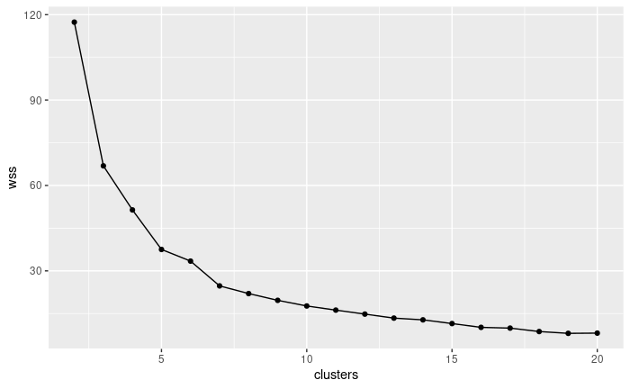

```r
ggplot(ssd,aes(x=clusters,y=wss))+geom_point()+
  geom_line()
```

## Interpreting scree plot

- Lower `wss` better.
- But lower for larger #clusters, harder to explain.
- Compromise: low-ish `wss` and low-ish #clusters.
- Look for “elbow” in plot.
- Idea: this is where `wss` decreases fast then slow.
- On our plot, small elbow at 6 clusters. Try this many clusters.

## Six clusters, using `nstart`

```r
vital.km6 = vital.s %>% select(-4) %>%
    kmeans(6,nstart=20)
vital.km6$size
```

```
[1] 15 30 24  2  8 18
```

```r
vital.km6$centers
```

```
       birth      death     infant
1 -0.4357690 -1.1438599 -0.7281108
2 -1.1737104 -0.1856375 -0.9534370
3  0.4160993 -0.5169988  0.2648754
4 -0.2199722  2.1116577 -0.4544435
5  1.3043848  2.1896567  1.9470306
6  1.2092406  0.7441347  1.0278003
```

```r
vital.6=tibble(country=vital.s$country,
               cluster=vital.km6$cluster)
```

## Cluster 1

```r
get_countries(1,vital.6)
```

```
 [1] "Albania"              "Chile"                "Israel"               "Kuwait"
 [5] "China"                "Singapore"            "Thailand"             "Argentina"
 [9] "Columbia"             "Venezuela"            "Bahrain"              "United_Arab_Emirates"
[13] "Hong_Kong"            "Malaysia"             "Sri_Lanka"
```

## Cluster 2

[output not shown]

```r
options(width=60)
get_countries(2,vital.6)
```

```
 [1] "Czechoslovakia"    "Hungary"
 [3] "Romania"           "USSR"
 [5] "Ukrainian_SSR"     "Uruguay"
 [7] "Finland"           "France"
 [9] "Greece"            "Italy"
[11] "Norway"            "Spain"
[13] "Switzerland"       "Austria"
[15] "Canada"            "Bulgaria"
[17] "Former_E._Germany" "Poland"
[19] "Yugoslavia"        "Byelorussia_SSR"
[21] "Belgium"           "Denmark"
[23] "Germany"           "Ireland"
[25] "Netherlands"       "Portugal"
[27] "Sweden"            "U.K."
[29] "Japan"             "U.S.A."
```

```r
options(width=50)
```

## Cluster 3

```r
get_countries(3,vital.6)
```

```
 [1] "Ecuador"      "Paraguay"     "Oman"         "Turkey"       "India"        "Mongolia"
 [7] "Pakistan"     "Algeria"      "Egypt"        "Libya"        "Morocco"      "South_Africa"
[13] "Zimbabwe"     "Brazil"       "Guyana"       "Peru"         "Iraq"         "Jordan"
[19] "Lebanon"      "Saudi_Arabia" "Indonesia"    "Philippines"  "Vietnam"      "Tunisia"
```

## Cluster 4

[output not shown]

```r
get_countries(4,vital.6)
```

```
[1] "Mexico" "Korea"
```

## Cluster 5

```r
get_countries(5,vital.6)
```

```
[1] "Afghanistan"  "Sierra_Leone" "Angola"       "Ethiopia"     "Gambia"       "Malawi"
[7] "Mozambique"   "Somalia"
```

## Cluster 6

[output not shown]

```r
get_countries(6,vital.6)
```

```
 [1] "Bolivia"    "Iran"       "Bangladesh" "Botswana"   "Gabon"      "Ghana"      "Namibia"
 [8] "Swaziland"  "Uganda"     "Zaire"      "Cambodia"   "Nepal"      "Congo"      "Kenya"
[15] "Nigeria"    "Sudan"      "Tanzania"   "Zambia"
```

## Comparing our 3 and 6-cluster solutions

```r
table(three=vital.km3$cluster,six=vital.km6$cluster)
```

```
     six
three  1  2  3  4  5  6
    1  9 30  0  1  0  0
    2  0  0  0  1  8 16
    3  6  0 24  0  0  2
```

## Getting a picture from `kmeans`

- Use multidimensional scaling (later)
- Use discriminant analysis on clusters found, treating them as “known” groups.

## MANOVA and discriminant analysis

- Go back to 1st 3 columns of `vital.s` (variables, standardized), plus `cf` (cluster as factor). `clus` (6 clusters).
- First, do they actually differ by group? (MANOVA):

```r
v <- vital.s %>% select(-4) %>% as.matrix()
cf <- as.factor(vital.km6$cluster)
vital.manova=manova(v~cf)
summary(vital.manova)
```

```
          Df Pillai approx F num Df den Df    Pr(>F)
cf         5 1.9215   32.427     15    273 < 2.2e-16 ***
Residuals 91
---
Signif. codes:  0 ‘***’ 0.001 ‘**’ 0.01 ‘*’ 0.05 ‘.’ 0.1 ‘ ’ 1
```

Oh yes.

## Discriminant analysis

- So what makes the groups different?
- Uses package `MASS` (loaded):

```r
vital.lda=lda(cf~birth+death+infant,data=vital.s)
vital.lda$svd
```

```
[1] 21.687195  8.851811  1.773006
```

```r
vital.lda$scaling
```

```
             LD1        LD2        LD3
birth  2.6879695 -1.1224202  1.9483853
death  0.6652712  2.7213044  0.6049358
infant 2.1111801 -0.7650912 -2.3542296
```

## To make a plot

- Get predictions first:

```r
vital.pred=predict(vital.lda)
d=data.frame(country=vital.s$country,
  cluster=vital.km6$cluster,vital.pred$x)
glimpse(d)
```

```
Rows: 97
Columns: 5
$ country <chr> "Albania", "Czechoslovakia", "Hungary", "Romania", "USSR", "Ukrainian_SSR", "Bolivia", "…
$ cluster <int> 1, 2, 2, 2, 2, 2, 6, 1, 3, 3, 2, 4, 2, 2, 2, 2, 2, 2, 2, 2, 2, 5, 6, 1, 1, 3, 3, 6, 1, 3…
$ LD1     <dbl> -2.74034473, -5.01874312, -4.97189595, -4.40612396, -3.87181416, -4.95502329, 7.04719692…
$ LD2     <dbl> -2.23114272, 2.54276395, 3.62910309, 1.68114304, 0.99643221, 2.45593006, 1.82235340, -1.…
$ LD3     <dbl> -0.086392118, 0.067491502, -0.149274227, -0.832426535, -0.134219177, -0.032543051, 0.559…
```

- `d` contains country names, cluster memberships and discriminant scores. Plot `LD1` against `LD2`, colouring points by cluster and labelling by country:

```r
g=ggplot(d,aes(x=LD1,y=LD2,colour=factor(cluster),
    label=country))+geom_point()+
    geom_text_repel(size=2)+guides(colour=F)
```

## The plot

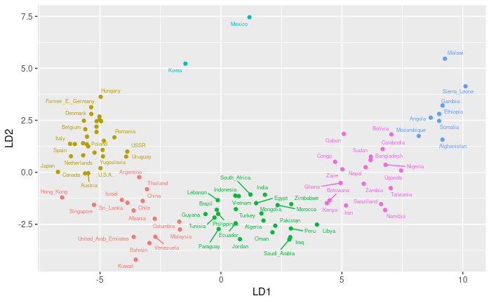

```r
g
```

## Final example: a hockey league

- An Ontario hockey league has teams in 21 cities. How can we arrange those teams into 4 geographical divisions?
- Distance data in spreadsheet.
- Take out spaces in team names.
- Save as “text/csv”.
  - Distances, so back to `hclust`.

## A map

[figure not shown]

Map 1

## Attempt 1

Read in data:

```r
my_url="http://ritsokiguess.site/datafiles/ontario-road-distances.csv"
ontario=read_csv(my_url)
ontario
```

| place | Barrie | Belleville | Brantford | Brockville | Cornwall | Hamilton | Huntsville | Kingston | Kitchener | London | Niagara Falls | North Bay | Ottawa | Owen Sound | Peterborough | Sarnia | Sault Ste Marie | St Catharines | Thunder Bay | Toronto | Windsor |
| --- | --- | --- | --- | --- | --- | --- | --- | --- | --- | --- | --- | --- | --- | --- | --- | --- | --- | --- | --- | --- | --- |
| Barrie | 0 | 260 | 190 | 405 | 500 | 145 | 125 | 330 | 180 | 260 | 220 | 250 | 430 | 120 | 160 | 315 | 595 | 200 | 1285 | 90 | 430 |
| Belleville | 260 | 0 | 290 | 155 | 250 | 255 | 280 | 75 | 280 | 360 | 315 | 400 | 230 | 360 | 105 | 455 | 805 | 300 | 1495 | 190 | 545 |
| Brantford | 190 | 290 | 0 | 420 | 535 | 40 | 300 | 340 | 40 | 85 | 105 | 430 | 500 | 185 | 230 | 185 | 755 | 90 | 1245 | 85 | 275 |
| Brockville | 405 | 155 | 420 | 0 | 95 | 405 | 405 | 80 | 425 | 510 | 465 | 420 | 110 | 510 | 255 | 605 | 850 | 445 | 1525 | 340 | 695 |
| Cornwall | 500 | 250 | 535 | 95 | 0 | 500 | 450 | 180 | 520 | 605 | 560 | 465 | 100 | 605 | 340 | 700 | 895 | 540 | 1570 | 435 | 790 |
| Hamilton | 145 | 255 | 40 | 405 | 500 | 0 | 270 | 330 | 60 | 125 | 70 | 395 | 470 | 190 | 200 | 220 | 740 | 50 | 1430 | 70 | 310 |
| Huntsville | 125 | 280 | 300 | 405 | 450 | 270 | 0 | 350 | 280 | 365 | 330 | 130 | 350 | 240 | 195 | 440 | 545 | 310 | 1230 | 215 | 555 |
| Kingston | 330 | 75 | 340 | 80 | 180 | 330 | 350 | 0 | 350 | 430 | 390 | 460 | 175 | 430 | 180 | 530 | 875 | 370 | 1565 | 260 | 620 |
| Kitchener | 180 | 280 | 40 | 425 | 520 | 60 | 280 | 350 | 0 | 100 | 130 | 405 | 490 | 150 | 220 | 190 | 750 | 110 | 1440 | 105 | 285 |
| London | 260 | 360 | 85 | 510 | 605 | 125 | 365 | 430 | 100 | 0 | 190 | 495 | 570 | 210 | 300 | 100 | 840 | 180 | 1525 | 185 | 190 |

[output cut: 11 more lines]

Make distance object

```r
ontario.d = ontario %>% select(-place) %>% as.dist()
ontario.d
```

```
                Barrie Belleville Brantford Brockville Cornwall Hamilton Huntsville Kingston Kitchener
Belleville         260
Brantford          190        290
Brockville         405        155       420
Cornwall           500        250       535         95
Hamilton           145        255        40        405      500
Huntsville         125        280       300        405      450      270
Kingston           330         75       340         80      180      330        350
Kitchener          180        280        40        425      520       60        280      350
London             260        360        85        510      605      125        365      430       100
Niagara Falls      220        315       105        465      560       70        330      390       130
North Bay          250        400       430        420      465      395        130      460       405
Ottawa             430        230       500        110      100      470        350      175       490
Owen Sound         120        360       185        510      605      190        240      430       150
Peterborough       160        105       230        255      340      200        195      180       220
Sarnia             315        455       185        605      700      220        440      530       190
Sault Ste Marie    595        805       755        850      895      740        545      875       750
St Catharines      200        300        90        445      540       50        310      370       110
Thunder Bay       1285       1495      1245       1525     1570     1430       1230     1565      1440
Toronto             90        190        85        340      435       70        215      260       105
Windsor            430        545       275        695      790      310        555      620       285
                London Niagara Falls North Bay Ottawa Owen Sound Peterborough Sarnia Sault Ste Marie
Belleville
Brantford
Brockville
Cornwall
Hamilton
Huntsville
Kingston
Kitchener
London
Niagara Falls      190
North Bay          495           455
Ottawa             570           530       365
Owen Sound         210           260       370    545
Peterborough       300           260       320    270        275
Sarnia             100           290       565    670        255          400
Sault Ste Marie    840           800       430    795        685          700    910
St Catharines      180            20       435    510        240          240    275             780
Thunder Bay       1525          1490      1105   1465       1375         1390   1600             690
```

[output cut: 8 more lines]

```
Huntsville
Kingston
Kitchener
London
Niagara Falls
North Bay
Ottawa
Owen Sound
Peterborough
Sarnia
Sault Ste Marie
St Catharines
Thunder Bay              1470
Toronto                   110        1375
Windsor                   365        1715     370
```

## Clustering: Ward’s method

```r
ontario.hc=hclust(ontario.d,method="ward.D")
cutree(ontario.hc,4)
```

```
         Barrie      Belleville       Brantford      Brockville        Cornwall        Hamilton
              1               2               1               2               2               1
     Huntsville        Kingston       Kitchener          London   Niagara Falls       North Bay
              3               2               1               1               1               3
         Ottawa      Owen Sound    Peterborough          Sarnia Sault Ste Marie   St Catharines
              2               1               2               1               3               1
    Thunder Bay         Toronto         Windsor
              4               1               1
```

## Plot, with 4 clusters

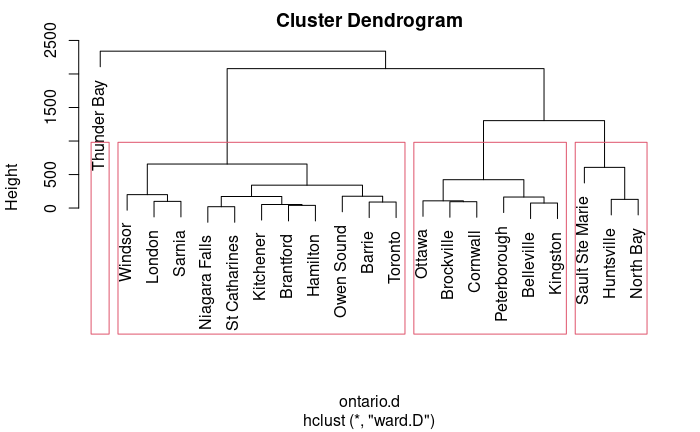

```r
plot(ontario.hc)
rect.hclust(ontario.hc,4)
```

## Comments

- Can’t have divisions of 1 team!
- “Southern” divisions way too big!
- Try splitting into more. I found 7 to be good:

## Seven clusters

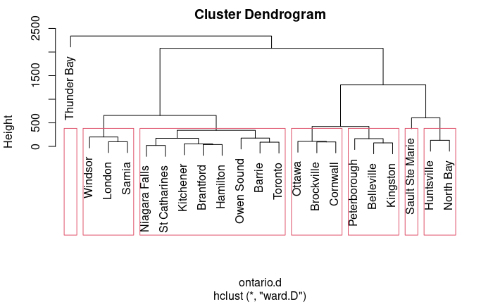

```r
plot(ontario.hc)
rect.hclust(ontario.hc,7)
```

## Another map

[figure not shown]

Map 2